# An Analysis of Amazon Book Review Data

Lucy(Ruoshi) Huang

7/31/2019

```r
library(dplyr)
library(tidytext)
library(textdata)
library(ggplot2)
library(stringr)
library(lubridate)
library(knitr)
library(DT)
load("AmazonFinal6.RData")
```

# 1 Looking at the Dataset

## 1.1 A Preliminary Analysis

First we can take a preliminary look at the dataset:

```r
Amazon_Reviews <- inner_join(Amazon6A, Amazon6B, by = "review_id")
Amazon_Reviews <- Amazon_Reviews %>% add_count(product_title, name = "review_count")
```

This is a dataset of book reviews on Amazon. It has a sample size of 458,986 observations (i.e. reviews) with 13 different variables. Information includes **the IDs**, which identify the review, the customer reviewer, and the book. It also includes **the title** of the book being reviewed, **the star rating** given to the book, **the review title and body**, **the review date**, **the votes for each review** (helpful votes and total votes), whether the purchase was **verified**, and whether the reviewer was a **Vine member**.

Upon initial observation, we notice the following:

1. There are **215,502 books** being reviewed in total in this dataset.
2. There are **384,743 unique customer IDs**. The person with the most number of reviews left **202 reviews**!
3. **72.90%** of the reviews are made by **verified purchasers** of the book (334,592 out of 458,986)
4. Only **1.93%** of these reviews are made by **Vine members** (8,841 out of 458,986)
5. There is less than **0.01%** of reviews with missing data (i.e. this sample dataset is **99.99%** complete). Among the total number of observations, 458,919 has no missing data. Therefore, this sample data is rather well-documented by Amazon. This also means we can safely remove rows with missing data without affecting our dataset too much.

## 1.2 Looking at the Star Ratings

When we look at book reviews on Amazon, we typically only trust those with a higher number of reviews. Thus, moving forward, we will restrict our analysis to only the books with over 50 reviews for a more meaningful analysis. After filtering and removing the rows with missing data, we are left with **19,329 observations**, which is still sufficient for our statistical analysis.

Then, we order these books by their mean star rating to find the **2 top-rated** and **2 lowest-rated** books. These four books are as follows:

```r
# the dataset filtered to only include those with over 50 reviews
Amazon_over50 <- Amazon_Reviews %>% filter(review_count >= 50) %>% na.omit()

# the mean ratings for each of the books with over 50 reviews
over50_meanrating <- Amazon_over50 %>%
  group_by(product_title) %>%
  summarise(mean_rating = mean(star_rating))

# get the mean ratings for the best 2 and worst 2 books
top2_meanrating <- head(arrange(over50_meanrating, desc(mean_rating)), n = 2)
low2_meanrating <- head(arrange(over50_meanrating, mean_rating), n = 2)
```

```r
kable(cbind(c(1, 2),top2_meanrating),
      col.names = c("Rank","Book Title", "Mean Star Rating"),
      caption = "Top 2 Books by Mean Star Rating")
```

Top 2 Books by Mean Star Rating

| Rank | Book Title | Mean Star Rating |
| --- | --- | --- |
| 1 | Goodnight, Goodnight Construction Site | 4.955056 |
| 2 | Go Pro: 7 Steps to Becoming a Network Marketing Professional | 4.950617 |

```r
kable(cbind(c(1, 2),low2_meanrating),
      col.names = c("Rank","Book Title", "Mean Star Rating"),
      caption = "Worst 2 Books by Mean Star Rating")
```

Worst 2 Books by Mean Star Rating

| Rank | Book Title | Mean Star Rating |
| --- | --- | --- |
| 1 | It Could Happen To Anyone: Why Battered Women Stay | 1.245902 |
| 2 | To Train Up a Child | 1.640000 |

```r
Amazon_over50 <- left_join(Amazon_over50, over50_meanrating, by = "product_title")
```

## 1.3 A Closer Look at these 4 Books via Sentiment Analysis of the Reviews

```r
afinn <- get_sentiments("afinn")

# Getting the sentiment for each review
sentiment <- Amazon_over50 %>%
    unnest_tokens(word, review_body) %>%
    inner_join(afinn, by = "word") %>%
    group_by(review_id) %>%
    summarize(sentiment_score = mean(value), word_count = n()) %>%
    filter(word_count >= 5)

# first instance of over50_sentiment
over50_sentiment <- left_join(sentiment, Amazon_over50,  by = "review_id")

sentiments_by_book <- over50_sentiment %>%
  group_by(product_title) %>%
  summarise(mean_sentiment = mean(sentiment_score))

book1_sentiment <- sentiments_by_book %>% filter(product_title == "Goodnight, Goodnight Construction Site")
book2_sentiment <- sentiments_by_book %>% filter(product_title == "Go Pro: 7 Steps to Becoming a Network Marketing Professional")
book3_sentiment <- sentiments_by_book %>% filter(product_title == "To Train Up a Child")
book4_sentiment <- sentiments_by_book %>% filter(product_title == "It Could Happen To Anyone: Why Battered Women Stay")

kable(cbind(c("Best", "Second Best", "Second Worst", "Worst"),rbind(book1_sentiment, book2_sentiment, book3_sentiment, book4_sentiment)),
      col.names = c("Rank by Rating", "Book Title", "Sentiment Score"),
      caption = "Sentiment Scores for the Best 2 and Worst 2 Books By Rating")
```

Sentiment Scores for the Best 2 and Worst 2 Books By Rating

| Rank by Rating | Book Title | Sentiment Score |
| --- | --- | --- |
| Best | Goodnight, Goodnight Construction Site | 1.8743590 |
| Second Best | Go Pro: 7 Steps to Becoming a Network Marketing Professional | 1.4244776 |
| Second Worst | To Train Up a Child | -0.5175360 |
| Worst | It Could Happen To Anyone: Why Battered Women Stay | -0.9182069 |

These sentiment scores appear to have a correlation with their ratings. **The lower the rating, the more negative the sentiment score**. We will be looking at this relationship further in our graphics later on.

Now, let’s take a look at what kind of words related to sentiment the customers like to use to describe their best and worst rated books. Words are currently ordered by their number of occurrences (‘count’) in the reviews, but you can toggle the column names to order them differently.

```r
# get the data for each book
book1 <- Amazon_over50 %>% filter(product_title == top2_meanrating$product_title[1])
book2 <- Amazon_over50 %>% filter(product_title == top2_meanrating$product_title[2])
book3 <- Amazon_over50 %>% filter(product_title == low2_meanrating$product_title[2])
book4 <- Amazon_over50 %>% filter(product_title == low2_meanrating$product_title[1])

book1_words <- book1 %>%
  unnest_tokens(word, review_body) %>%
  count(word, name = "count", sort = TRUE) %>%
  ungroup() %>%
  inner_join(afinn, by = "word") %>%
  group_by(word) %>%
  mutate(contribution = value * count) %>%
  arrange(desc(count))

book2_words <- book2 %>%
  unnest_tokens(word, review_body) %>%
  count(word, name = "count", sort = TRUE) %>%
  ungroup() %>%
  inner_join(afinn, by = "word") %>%
  group_by(word) %>%
  mutate(contribution = value * count) %>%
  arrange(desc(count))

book3_words <- book3 %>%
  unnest_tokens(word, review_body) %>%
  count(word, name = "count", sort = TRUE) %>%
  ungroup() %>%
  inner_join(afinn, by = "word") %>%
  group_by(word) %>%
  mutate(contribution = value * count) %>%
  arrange(desc(count))

book4_words <- book4 %>%
  unnest_tokens(word, review_body) %>%
  count(word, name = "count", sort = TRUE) %>%
  ungroup() %>%
  inner_join(afinn, by = "word") %>%
  group_by(word) %>%
  mutate(contribution = value * count) %>%
  arrange(desc(count))
```

```r
datatable(book1_words, caption = 'Sentiment Words for "Goodnight, Goodnight Construction Site"')
```

|  | word | count | value | contribution |
| --- | --- | --- | --- | --- |
| 1 | great | 19 | 3 | 57 |
| 2 | good | 18 | 3 | 54 |
| 3 | favorite | 16 | 2 | 32 |
| 4 | love | 15 | 3 | 45 |
| 5 | cute | 12 | 2 | 24 |
| 6 | perfect | 10 | 3 | 30 |
| 7 | recommend | 9 | 2 | 18 |
| 8 | wonderful | 9 | 4 | 36 |
| 9 | loved | 8 | 3 | 24 |
| 10 | enjoy | 5 | 2 | 10 |

[output cut: 57 more lines]

```r
datatable(book2_words, caption = 'Sentiment Words for "Go Pro: 7 Steps to Becoming a Network Marketing Professional"')
```

|  | word | count | value | contribution |
| --- | --- | --- | --- | --- |
| 1 | easy | 16 | 1 | 16 |
| 2 | great | 13 | 3 | 39 |
| 3 | recommend | 11 | 2 | 22 |
| 4 | success | 11 | 2 | 22 |
| 5 | better | 9 | 2 | 18 |
| 6 | thanks | 9 | 2 | 18 |
| 7 | amazing | 8 | 4 | 32 |
| 8 | best | 8 | 3 | 24 |
| 9 | good | 8 | 3 | 24 |
| 10 | thank | 8 | 2 | 16 |

[output cut: 96 more lines]

```r
datatable(book3_words, caption = 'Sentiment Words for "To Train Up a Child"')
```

|  | word | count | value | contribution |
| --- | --- | --- | --- | --- |
| 1 | abuse | 25 | -3 | -75 |
| 2 | no | 19 | -1 | -19 |
| 3 | love | 17 | 3 | 51 |
| 4 | god | 14 | 1 | 14 |
| 5 | like | 10 | 2 | 20 |
| 6 | fear | 9 | -2 | -18 |
| 7 | help | 8 | 2 | 16 |
| 8 | hell | 7 | -4 | -28 |
| 9 | beating | 6 | -1 | -6 |
| 10 | death | 6 | -2 | -12 |

[output cut: 222 more lines]

```r
datatable(book4_words, caption = 'Sentiment Words for "It Could Happen To Anyone: Why Battered Women Stay"')
```

|  | word | count | value | contribution |
| --- | --- | --- | --- | --- |
| 1 | no | 32 | -1 | -32 |
| 2 | victims | 31 | -3 | -93 |
| 3 | abuse | 29 | -3 | -87 |
| 4 | victim | 27 | -3 | -81 |
| 5 | like | 22 | 2 | 44 |
| 6 | violence | 20 | -3 | -60 |
| 7 | bias | 18 | -1 | -18 |
| 8 | abused | 14 | -3 | -42 |
| 9 | hate | 14 | -3 | -42 |
| 10 | wrong | 12 | -2 | -24 |

[output cut: 252 more lines]

Notice that the best 2 books have similar sentiment words in their reviews, and the same goes for the worst 2 books.

1. For the best 2 books, customers seem to be using generally the same/similar positive adjectives to describe the books.
2. For the worst 2 books, there seems to be a common theme of **abuse** / **violence** in both books that are often brought up in the reviews. This appears to be a main contribution towards the negative sentiment.

While the positive sentiments seem rather homogeneous and mundane, the negative sentiments seem to have a reason behind it. Here, I am seeing a **value-based dissastifaction**. Something related to abuse, violence, and victims is triggering the customers, causing them to react very negatively towards the books. After reading some of the reviews in full, they appear to support this hypothesis, since it seems like most reviewers are mostly unhappy about the authors’ **‘twisted’ values**, which are conveyed through the book.

Notice also, if we order the sentiment words in each book by **ascending order of value** (i.e. negative sentiment values first), as we move from the top-rated books to the low-rated books, these words get much more **pungent**, and there is much more profanity (you may take a look for yourself by ordering by value in the table). Reviewers are not afraid to use strong harsh words when it comes to negative reviews.

# 2 Visualizing Ratings and Sentiments

## 2.1 Choice of Variables

In the graphic below, I visualized the following variables:

1. The **star rating** of the book by each review: the extremes (1 and 5) are generally more interesting than the middle ratings (2 to 4), so I called 1 ‘low’, 5 ‘high’, and grouped 2-4 together as ‘mid’ when graphing.
2. The **helpfulness** of the review as determined by the votes: helpfulness is calculated by **(helpful_votes/total_votes) * 100**. Since this index would not be very accurate if the total votes are too low, we filter to keep only those with more than 5 total votes.
3. The **sentiment score** of each review: I used color to illustrate this, with red being negative sentiment and green being positive.
4. The **year** the review was made: I made this one of the facet variables to see changes across different years.
5. Whether the review was associated with a **verified purchase**: I made this the other facet variable to see if this aspect will influence the rating/sentiment/helpfulness of the reviews.

```r
# the same dataframe but with star ratings factored as low, mid, high, and verified purchase factored
over50_sentiment_factored <- over50_sentiment %>%
  mutate(star_rating = cut(star_rating, breaks = c(0, 1, 4, 5), labels = c("low", "mid", "high"))) %>%
  mutate(verified_purchase = factor(verified_purchase, levels = c("N", "Y"), labels = c("Not Verified (No)", "Verifed (Yes)")))

# filter out the ones with too few votes
filtered_over50 <- over50_sentiment_factored %>% filter(total_votes > 5)

filtered_over50 <- filtered_over50 %>%
  mutate(helpfulness = helpful_votes/total_votes * 100) %>%
  mutate(review_length = str_length(review_body)) %>%
  mutate(review_date = ymd(review_date)) %>%
  mutate(review_year = year(review_date))
```

## 2.2 Choice of Plots

1. I chose a **violin plot** to display the density of the datapoints. This can very effectively show the the distribution regarding helpfulness of reviews.
2. I added the **boxplot** on top to more accurately display the quartiles of helpfuness for each level of rating.
3. The specific datapoints were also plotted in the back to display both of volume of reviews as well as the general sentiment for a particular category.

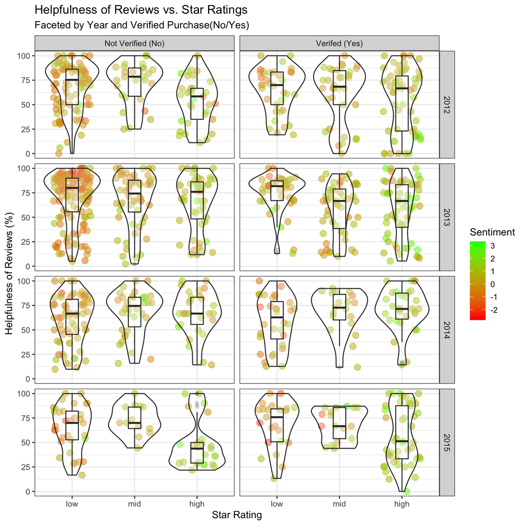

```r
ggplot(filtered_over50, aes(x = star_rating, y = helpfulness, col = sentiment_score)) +
  geom_jitter(size = 3, alpha = 0.5, width = 0.3) +
  scale_color_gradient(low = "red", high = "green") +
  geom_violin(alpha = 0.2) +
  geom_boxplot(width = 0.2, alpha = 0.2) +
  facet_grid(review_year~verified_purchase) +
  labs(title = "Helpfulness of Reviews vs. Star Ratings",
       subtitle = "Faceted by Year and Verified Purchase(No/Yes)",
       x = "Star Rating", y = "Helpfulness of Reviews (%)", colour = "Sentiment" ) +
  theme_bw()
```

From this graphic, we can notice the following:

1. The **lower ratings** tends to have more **negative sentiments**, and the **higher ratings** more **positive**.
2. People generally found the **lower ratings** to be **more helpful**.
3. The **verified reviews** were generally **more positive** in sentiment than the non-verified ones.
4. **Verified reviews** also have **fewer low ratings** than non-verified ones.
5. However, people did **not** distinctively seem to find the verified purchases reviews more useful than the non-verified purchases reviews.
6. Generally, people found the older years’ reviews more helpful than the newer ones. However, do note that since this graphic removed points that only received few votes, this difference could potentially be because the newer reviews have yet to have garnered any votes, thus skewing the data.

This is all useful information for customers, booksellers, and Amazon. For example, Amazon could use this to review the effectiveness of their Verified Purchase feature. Some conclusions are more intuitive than others; It is natural for people to give lower ratings if they have more negative sentiment towards the book. Also, when we look at product reviews onlines, we typically try to look for its faults, so we’d usually find the lower ratings more useful in determining whether or not we buy the product.

**Note:**  
Initial exploration graphing suggested that the following **two variables** do not have that strong of a correlation with the rating or the sentiment, thus they were ultimately omitted from the final graphic. However, the **lack of correlation** do provide some insight:

1. **Review Length**: this suggests it is not necessarily the longer the review the better.
2. **Review Month**: this suggests sentiments/ratings of these books do not appear largely influenced by seasonal changes.

# 3 Further Exploration

## 3.1 Some Interesting Findings

Looking at the graph, there was an anomaly that stood out to me: **In 2015, the higher ratings were deemed especially unhelpful** by customers, for both verified and non-verified reviews (although more so for the non-verified). In the process of learning why this was so, I made some interesting discoveries.

Since we see that for these high ratings the non-verified reviews had a bigger anomaly than the verified, my hypothesis was that there were some fake reviews that were discovered and downvoted by vigilant customers.

To test this, I filtered to isolate those particular data points of interest (by year 2015, helpfulness less than 50%, and a high star rating). Then I took a look at the **mean review length** to see if there were many short or blank ones, which may indicate fake reviews. However, I discovered that the reviews are mostly of reasonable length (i.e. sufficiently long).

```r
closer_look1 <- filtered_over50 %>% filter(review_year == 2015, helpfulness < 50, star_rating == "high")
kable(closer_look1 %>% summarise(mean_review_length = mean(review_length), mean_sentiment = mean(sentiment_score)),
      col.names = c("Mean Review Length", "Mean Sentiment Score"))
```

| Mean Review Length | Mean Sentiment Score |
| --- | --- |
| 729.5641 | 1.220038 |

So next, I proceeded to see how many reviews there actually were fitting these filter categories. I found that there were just 39, which meant the size was small enough for me to view the data directly.

```r
dim(closer_look1)
```

```
[1] 39 21
```

Taking a closer look at the data, I made a rather shocking discovery: they were mostly reviews of the same book! *The Food Babe Way: Break Free from the Hidden Toxins in Your Food and Lose Weight, Look Years Younger, and Get Healthy in Just 21 Days!*

There is something very peculiar about this book, so I searched for all its reviews within **the original dataset**, then calculated **the mean helpfulness** of all of the book’s reviews, and discovered the value was surprisingly low (recall helpfulness is out of 100), especially given it has such a high star rating.

```r
closer_look2 <- Amazon_Reviews %>% filter(product_title == "The Food Babe Way: Break Free from the Hidden Toxins in Your Food and Lose Weight, Look Years Younger, and Get Healthy in Just 21 Days!")
kable(closer_look2 %>% summarise(mean_helpfulness = mean(helpful_votes/total_votes * 100), mean_rating = mean(star_rating)),
      col.names = c("Mean Helpfulness", "Mean Rating"))
```

| Mean Helpfulness | Mean Rating |
| --- | --- |
| 36.04799 | 4.280303 |

Even more striking, I discovered that **the non-verified reviews** were almost all made **around the same time in 2015 February**! This seems indicative of something suspicious about them.

## 3.2 Digging Deeper

Out of curiosity about this book and its author, I did some research online. I discovered that the author is a rather popular healthy-food blogger. However, her works are considered as **pseudoscience** by many scientists. In addition, she has a history of controversy regarding financial interest in her marketing and partnerships with organic and non-GMO brands. Therefore, compounded with the peculiarity we see in the data, one might reasonably speculate that there was potentially foul play involved in all these high ratings. Perhaps she paid people to leave her positive reviews, or fanatic followers of her pseudoscience are leaving these reviews… but of course we do not have enough evidence to be conclusive.  
For further reference, here are some links to related articles and websites.  
1. [Wikepedia page for the author Vani Hari](https://en.wikipedia.org/wiki/Vani_Hari)  
2. [NPR article: “Is the Food Babe a Fearmonger?”](https://www.npr.org/sections/thesalt/2014/12/04/364745790/food-babe-or-fear-babe-as-activist-s-profile-grows-so-do-her-critics)

## 3.3 Conclusion and Suggestions

We know that Amazon has recently disabled the **“not helpful”** button to reduce abuse. However, our evaluation shows that there is a potential problem with this decision.

If we look at Amazon’s website now. We see that they **only display the number of helpful reviews**. I went to the website and searched for one of the **unhelpful** comments on this book. As shown below, we can now only see that there are **34 helpful votes**, and just looking at the content, it seems like this review is very legit. However, from our dataset, we know that there were **actually 74 total votes**, meaning there were **40 downvotes** for this review that customers can **no longer see** on the website. Yet this could have heavily influenced a customer’s buying decision.

[figure not shown]

Therefore, although we cannot make any concrete conclusion about whether there was manipulation involved in the reviews, we **can** conclude that removing the downvotes feature does potentially give **incorrect bias** to a buying customer. Therefore, taking this information into account, Amazon may want to **reconsider the downvote feature** moving forward.